# Weight sensitivity

## Table 1. Weight misspecification (non-null GWAS)

Per-replicate percentage change in *r*<sup>2</sup> with the true genetic value when PRS-LDmix uses a weight off from w<sub>0</sub> by the column offset, relative to PRS-LDmix at w<sub>0</sub>; negative values mean lower accuracy. The change is relative, *r*<sup>2</sup>(w)/*r*<sup>2</sup>(w<sub>0</sub>) − 1 per replicate, so the threshold is a fraction of the generating-weight *r*<sup>2</sup>, not an absolute difference. Bold: the lower 95% bound falls below −2%, the acceptable relative loss fixed before the curves were examined; unbolded cells are within it. –: the weight is outside [0, 1]. Exploratory analysis, not curated paper evidence. Chromosome 22, fixed 250 kb LD blocks, PRS-CS with automatic φ and default sampler settings; replicates 1–20 per setting. w<sub>0</sub> is the generating weight on the first-listed ancestry; PRS-LDmix at w = 1 and 0 is first- and second-ancestry PRS-CS. Square brackets are pointwise 95% t intervals over replicates, paired within replicate; they are exploratory and not adjusted for the number of settings and weights.

| Pair | GWAS mix | Targets | Relative *r*<sup>2</sup> change (%) when the weight is off by -0.2 | Relative *r*<sup>2</sup> change (%) when the weight is off by -0.1 | Relative *r*<sup>2</sup> change (%) when the weight is off by +0.1 | Relative *r*<sup>2</sup> change (%) when the weight is off by +0.2 |
| --- | --- | --- | --- | --- | --- | --- |
| EUR + ASN | 90:10 | EUR | −1.0 [−1.8, −0.2] | −0.3 [−0.9, +0.4] | +0.2 [−0.5, +0.8] | – |
|  |  | ASN | −1.0 [−2.0, 0.0] | −0.5 [−1.2, +0.3] | +0.5 [−0.4, +1.4] | – |
|  | 70:30 | EUR | −0.7 [−1.4, 0.0] | 0.0 [−0.4, +0.4] | +0.4 [−0.2, +0.9] | 0.0 [−0.7, +0.7] |
|  |  | ASN | −0.7 [−1.7, +0.2] | +0.2 [−0.4, +0.7] | +1.1 [+0.4, +1.7] | +0.5 [−0.2, +1.2] |
|  | 50:50 | EUR | −0.3 [−1.0, +0.4] | +0.3 [−0.6, +1.1] | +0.1 [−0.4, +0.7] | +0.2 [−0.5, +1.0] |
|  |  | ASN | −0.3 [−1.0, +0.3] | +0.4 [−0.4, +1.2] | +0.5 [0.0, +1.0] | +0.5 [−0.1, +1.2] |
| EUR + SAS | 90:10 | EUR | −0.7 [−1.2, −0.2] | −0.3 [−0.8, +0.2] | +0.1 [−0.3, +0.6] | – |
|  |  | SAS | **−0.5 [−2.6, +1.5]** | +0.2 [−1.5, +2.0] | +0.7 [−1.2, +2.6] | – |
|  | 70:30 | EUR | +0.6 [0.0, +1.1] | +0.5 [−0.1, +1.1] | +0.1 [−0.6, +0.7] | −0.5 [−1.0, +0.1] |
|  |  | SAS | +0.2 [−1.2, +1.7] | +0.4 [−1.1, +2.0] | −0.5 [−1.5, +0.6] | **−1.1 [−2.5, +0.2]** |
|  | 50:50 | EUR | +0.9 [+0.6, +1.3] | +0.4 [0.0, +0.7] | −1.5 [−2.0, −0.9] | **−2.3 [−3.0, −1.7]** |
|  |  | SAS | +1.6 [+0.1, +3.1] | +1.7 [+0.4, +3.0] | **−2.2 [−4.0, −0.4]** | **−2.7 [−4.9, −0.5]** |
| EUR + AFR | 90:10 | EUR | −0.8 [−1.4, −0.2] | −0.3 [−0.9, +0.3] | +0.1 [−0.6, +0.7] | – |
|  |  | AFR | **−0.3 [−2.3, +1.6]** | +1.5 [−0.5, +3.5] | **−0.2 [−2.7, +2.4]** | – |
|  | 70:30 | EUR | +1.3 [+0.5, +2.1] | +1.1 [+0.5, +1.7] | **−1.2 [−2.2, −0.2]** | **−3.2 [−4.9, −1.4]** |
|  |  | AFR | +7.0 [+4.3, +9.7] | +4.5 [+2.5, +6.6] | **−3.1 [−6.1, −0.2]** | **−10.1 [−13.4, −6.9]** |
|  | 50:50 | EUR | +4.2 [+2.9, +5.5] | +2.1 [+1.4, +2.8] | **−3.0 [−3.8, −2.1]** | **−6.4 [−7.9, −4.8]** |
|  |  | AFR | +10.4 [+7.2, +13.6] | +5.6 [+3.8, +7.3] | **−6.3 [−8.3, −4.3]** | **−12.8 [−16.2, −9.4]** |
| ASN + AFR | 90:10 | ASN | −1.0 [−1.7, −0.4] | −0.7 [−1.2, −0.2] | +0.3 [−0.2, +0.8] | – |
|  |  | AFR | +1.4 [−1.0, +3.9] | +0.3 [−1.0, +1.5] | **+0.1 [−2.8, +2.9]** | – |
|  | 70:30 | ASN | +1.5 [+0.5, +2.5] | +0.8 [+0.1, +1.5] | **−1.8 [−2.4, −1.1]** | **−3.6 [−5.0, −2.2]** |
|  |  | AFR | +7.8 [+5.2, +10.4] | +5.1 [+2.7, +7.4] | **−5.1 [−7.1, −3.1]** | **−10.6 [−14.0, −7.3]** |
|  | 50:50 | ASN | +5.4 [+4.3, +6.5] | +2.8 [+2.3, +3.3] | **−3.3 [−3.9, −2.7]** | **−7.1 [−8.2, −6.0]** |
|  |  | AFR | +10.5 [+7.1, +13.9] | +5.1 [+2.9, +7.4] | **−5.4 [−7.4, −3.4]** | **−11.2 [−14.7, −7.7]** |

## Table 2. PRS-LDmix at the generating weight against the single panels (non-null GWAS)

Paired differences in *r*<sup>2</sup> (positive favours PRS-LDmix) and geometric-mean percentage change in mean squared error against the true genetic value (negative favours PRS-LDmix). Exploratory analysis, not curated paper evidence. Chromosome 22, fixed 250 kb LD blocks, PRS-CS with automatic φ and default sampler settings; replicates 1–20 per setting. w<sub>0</sub> is the generating weight on the first-listed ancestry; PRS-LDmix at w = 1 and 0 is first- and second-ancestry PRS-CS. Square brackets are pointwise 95% t intervals over replicates, paired within replicate; they are exploratory and not adjusted for the number of settings and weights.

| Pair | GWAS mix | Targets | PRS-LDmix minus first-ancestry PRS-CS *r*<sup>2</sup> | PRS-LDmix minus first-ancestry PRS-CS MSE (%) | PRS-LDmix minus second-ancestry PRS-CS *r*<sup>2</sup> | PRS-LDmix minus second-ancestry PRS-CS MSE (%) |
| --- | --- | --- | --- | --- | --- | --- |
| EUR + ASN | 90:10 | EUR | −0.0006 [−0.0045, +0.0032] | +0.7 [−0.5, +2.1] | +0.0829 [+0.0613, +0.1044] | −56.8 [−64.0, −48.1] |
|  |  | ASN | −0.0026 [−0.0077, +0.0025] | +0.6 [−0.4, +1.7] | +0.0705 [+0.0604, +0.0806] | −23.0 [−27.2, −18.6] |
|  | 70:30 | EUR | +0.0017 [−0.0033, +0.0067] | +0.1 [−1.7, +1.9] | +0.0463 [+0.0299, +0.0627] | −30.2 [−39.4, −19.7] |
|  |  | ASN | −0.0026 [−0.0084, +0.0033] | +0.1 [−1.3, +1.5] | +0.0352 [+0.0252, +0.0452] | −11.0 [−14.5, −7.3] |
|  | 50:50 | EUR | +0.0065 [+0.0005, +0.0125] | −2.1 [−4.0, −0.3] | +0.0140 [+0.0057, +0.0223] | −9.0 [−13.3, −4.4] |
|  |  | ASN | +0.0067 [+0.0003, +0.0130] | −5.5 [−8.7, −2.3] | +0.0106 [+0.0048, +0.0163] | −3.3 [−5.2, −1.5] |
| EUR + SAS | 90:10 | EUR | −0.0008 [−0.0031, +0.0016] | +0.7 [−0.3, +1.7] | +0.0209 [+0.0127, +0.0290] | −23.7 [−28.0, −19.1] |
|  |  | SAS | −0.0040 [−0.0125, +0.0046] | +1.0 [−1.0, +3.1] | +0.0191 [+0.0060, +0.0321] | −11.7 [−15.3, −7.9] |
|  | 70:30 | EUR | +0.0057 [+0.0030, +0.0083] | −1.5 [−3.0, 0.0] | +0.0037 [−0.0010, +0.0085] | −21.5 [−23.9, −19.1] |
|  |  | SAS | +0.0129 [+0.0068, +0.0191] | −7.2 [−9.4, −5.0] | +0.0072 [−0.0012, +0.0157] | −11.4 [−13.5, −9.2] |
|  | 50:50 | EUR | +0.0191 [+0.0165, +0.0218] | −9.2 [−10.0, −8.3] | −0.0050 [−0.0074, −0.0026] | −19.6 [−20.8, −18.4] |
|  |  | SAS | +0.0225 [+0.0168, +0.0282] | −28.6 [−30.0, −27.0] | −0.0059 [−0.0111, −0.0007] | −5.1 [−7.0, −3.3] |
| EUR + AFR | 90:10 | EUR | −0.0003 [−0.0040, +0.0033] | +1.8 [+0.2, +3.3] | +0.0567 [+0.0427, +0.0707] | −67.8 [−72.4, −62.5] |
|  |  | AFR | −0.0006 [−0.0101, +0.0089] | 0.0 [−2.9, +2.9] | +0.0411 [+0.0178, +0.0645] | −32.8 [−37.7, −27.5] |
|  | 70:30 | EUR | +0.0262 [+0.0152, +0.0372] | −9.6 [−15.2, −3.5] | +0.0092 [−0.0036, +0.0220] | −53.4 [−57.3, −49.1] |
|  |  | AFR | +0.0283 [+0.0224, +0.0343] | −43.2 [−53.0, −31.2] | −0.0167 [−0.0314, −0.0020] | +2.6 [−12.0, +19.8] |
|  | 50:50 | EUR | +0.0694 [+0.0607, +0.0781] | −31.1 [−36.8, −24.8] | −0.0196 [−0.0266, −0.0126] | −40.5 [−43.0, −37.8] |
|  |  | AFR | +0.0405 [+0.0269, +0.0540] | −81.9 [−84.6, −78.9] | −0.0239 [−0.0287, −0.0190] | +36.5 [+21.8, +53.0] |
| ASN + AFR | 90:10 | ASN | −0.0015 [−0.0045, +0.0014] | +2.3 [+1.1, +3.5] | +0.0966 [+0.0777, +0.1155] | −82.7 [−85.2, −79.8] |
|  |  | AFR | +0.0011 [−0.0084, +0.0106] | −2.2 [−5.4, +1.2] | +0.0362 [+0.0192, +0.0531] | −43.6 [−47.2, −39.7] |
|  | 70:30 | ASN | +0.0352 [+0.0256, +0.0447] | −11.0 [−15.3, −6.5] | +0.0240 [+0.0068, +0.0412] | −66.6 [−70.3, −62.6] |
|  |  | AFR | +0.0309 [+0.0262, +0.0355] | −55.3 [−63.5, −45.2] | −0.0227 [−0.0347, −0.0108] | +10.6 [−5.8, +29.8] |
|  | 50:50 | ASN | +0.0837 [+0.0775, +0.0899] | −29.4 [−32.5, −26.1] | −0.0283 [−0.0364, −0.0203] | −47.0 [−49.5, −44.3] |
|  |  | AFR | +0.0323 [+0.0225, +0.0421] | −85.3 [−87.3, −83.1] | −0.0228 [−0.0259, −0.0197] | +49.5 [+35.1, +65.4] |

## Table 3. Recovery of the composition by null LD fit

Per replicate, the weight in 0, 0.1, …, 1 that minimises the Gaussian LD-fit loss (ridge 0.001) of the mixed panel against the null GWAS z-scores; mean (Monte Carlo SE) over replicates. The null GWAS is simulated separately from the non-null GWAS in Tables 1, 2 and 4, so this asks only whether LD fit recovers the composition; it does not validate LD fit as a way to choose the weight for prediction. Exploratory analysis, not curated paper evidence. Chromosome 22, fixed 250 kb LD blocks, PRS-CS with automatic φ and default sampler settings; replicates 1–20 per setting. w<sub>0</sub> is the generating weight on the first-listed ancestry; PRS-LDmix at w = 1 and 0 is first- and second-ancestry PRS-CS. Square brackets are pointwise 95% t intervals over replicates, paired within replicate; they are exploratory and not adjusted for the number of settings and weights.

| Pair | GWAS mix | Weight minimising null LD-fit loss, per replicate Mean (SE) | Weight minimising null LD-fit loss, per replicate Mean absolute error | Weight minimising null LD-fit loss, per replicate Exactly w<sub>0</sub> (%) | Weight minimising null LD-fit loss, per replicate Within ±0.1 (%) |
| --- | --- | --- | --- | --- | --- |
| EUR + ASN | 90:10 | 0.90 (0.00) | 0.00 | 100 | 100 |
|  | 70:30 | 0.70 (0.00) | 0.00 | 100 | 100 |
|  | 50:50 | 0.50 (0.00) | 0.00 | 100 | 100 |
| EUR + SAS | 90:10 | 0.90 (0.00) | 0.00 | 100 | 100 |
|  | 70:30 | 0.78 (0.01) | 0.08 | 25 | 100 |
|  | 50:50 | 0.64 (0.01) | 0.14 | 0 | 60 |
| EUR + AFR | 90:10 | 0.90 (0.00) | 0.00 | 100 | 100 |
|  | 70:30 | 0.69 (0.01) | 0.01 | 90 | 100 |
|  | 50:50 | 0.51 (0.01) | 0.01 | 85 | 100 |
| ASN + AFR | 90:10 | 0.90 (0.00) | 0.00 | 100 | 100 |
|  | 70:30 | 0.70 (0.00) | 0.00 | 100 | 100 |
|  | 50:50 | 0.53 (0.01) | 0.02 | 75 | 100 |

## Table 4. Oracle benchmarks (retrospective)

The weight with the highest mean *r*<sup>2</sup>, and the better of the two single panels, both chosen with the true genetic values of the same target individuals; mean (Monte Carlo SE). These choices are not available to a user and are optimistic by construction; they show how much a perfectly informed choice could gain over the generating weight. Exploratory analysis, not curated paper evidence. Chromosome 22, fixed 250 kb LD blocks, PRS-CS with automatic φ and default sampler settings; replicates 1–20 per setting. w<sub>0</sub> is the generating weight on the first-listed ancestry; PRS-LDmix at w = 1 and 0 is first- and second-ancestry PRS-CS. Square brackets are pointwise 95% t intervals over replicates, paired within replicate; they are exploratory and not adjusted for the number of settings and weights.

| Pair | GWAS mix | Targets | PRS-LDmix at w<sub>0</sub> *r*<sup>2</sup> | Best weight (oracle) Weight | Best weight (oracle) *r*<sup>2</sup> | Better single panel (oracle) Panel | Better single panel (oracle) *r*<sup>2</sup> |
| --- | --- | --- | --- | --- | --- | --- | --- |
| EUR + ASN | 90:10 | EUR | 0.569 (0.011) | 1.0 | 0.569 (0.010) | EUR | 0.569 (0.010) |
|  |  | ASN | 0.548 (0.013) | 1.0 | 0.551 (0.012) | EUR | 0.551 (0.012) |
|  | 70:30 | EUR | 0.591 (0.010) | 0.8 | 0.594 (0.010) | EUR | 0.590 (0.009) |
|  |  | ASN | 0.587 (0.011) | 0.8 | 0.593 (0.011) | EUR | 0.590 (0.010) |
|  | 50:50 | EUR | 0.596 (0.010) | 0.4 | 0.597 (0.009) | EUR | 0.589 (0.009) |
|  |  | ASN | 0.602 (0.011) | 0.7 | 0.605 (0.011) | EUR | 0.596 (0.010) |
| EUR + SAS | 90:10 | EUR | 0.548 (0.011) | 1.0 | 0.549 (0.011) | EUR | 0.549 (0.011) |
|  |  | SAS | 0.516 (0.017) | 1.0 | 0.520 (0.018) | EUR | 0.520 (0.018) |
|  | 70:30 | EUR | 0.433 (0.009) | 0.5 | 0.435 (0.010) | SAS | 0.429 (0.010) |
|  |  | SAS | 0.388 (0.018) | 0.6 | 0.389 (0.017) | SAS | 0.381 (0.017) |
|  | 50:50 | EUR | 0.249 (0.006) | 0.0 | 0.254 (0.007) | SAS | 0.254 (0.007) |
|  |  | SAS | 0.200 (0.014) | 0.0 | 0.206 (0.014) | SAS | 0.206 (0.014) |
| EUR + AFR | 90:10 | EUR | 0.541 (0.009) | 1.0 | 0.542 (0.009) | EUR | 0.542 (0.009) |
|  |  | AFR | 0.393 (0.019) | 0.8 | 0.399 (0.019) | EUR | 0.394 (0.020) |
|  | 70:30 | EUR | 0.451 (0.012) | 0.3 | 0.458 (0.011) | AFR | 0.442 (0.010) |
|  |  | AFR | 0.235 (0.026) | 0.3 | 0.253 (0.025) | AFR | 0.252 (0.023) |
|  | 50:50 | EUR | 0.286 (0.012) | 0.0 | 0.305 (0.010) | AFR | 0.305 (0.010) |
|  |  | AFR | 0.130 (0.019) | 0.0 | 0.154 (0.019) | AFR | 0.154 (0.019) |
| ASN + AFR | 90:10 | ASN | 0.570 (0.010) | 1.0 | 0.571 (0.010) | ASN | 0.571 (0.010) |
|  |  | AFR | 0.373 (0.021) | 0.6 | 0.378 (0.019) | ASN | 0.372 (0.020) |
|  | 70:30 | ASN | 0.478 (0.013) | 0.3 | 0.487 (0.012) | AFR | 0.454 (0.014) |
|  |  | AFR | 0.210 (0.023) | 0.0 | 0.232 (0.021) | AFR | 0.232 (0.021) |
|  | 50:50 | ASN | 0.314 (0.013) | 0.0 | 0.342 (0.012) | AFR | 0.342 (0.012) |
|  |  | AFR | 0.137 (0.019) | 0.0 | 0.160 (0.019) | AFR | 0.160 (0.019) |

## Figure 1. *r*<sup>2</sup> across weights

Mean percentage change in *r*<sup>2</sup> relative to PRS-LDmix at the generating weight (dashed vertical line), with pointwise 95% intervals; grey band ±2%. Free y-axis per row.

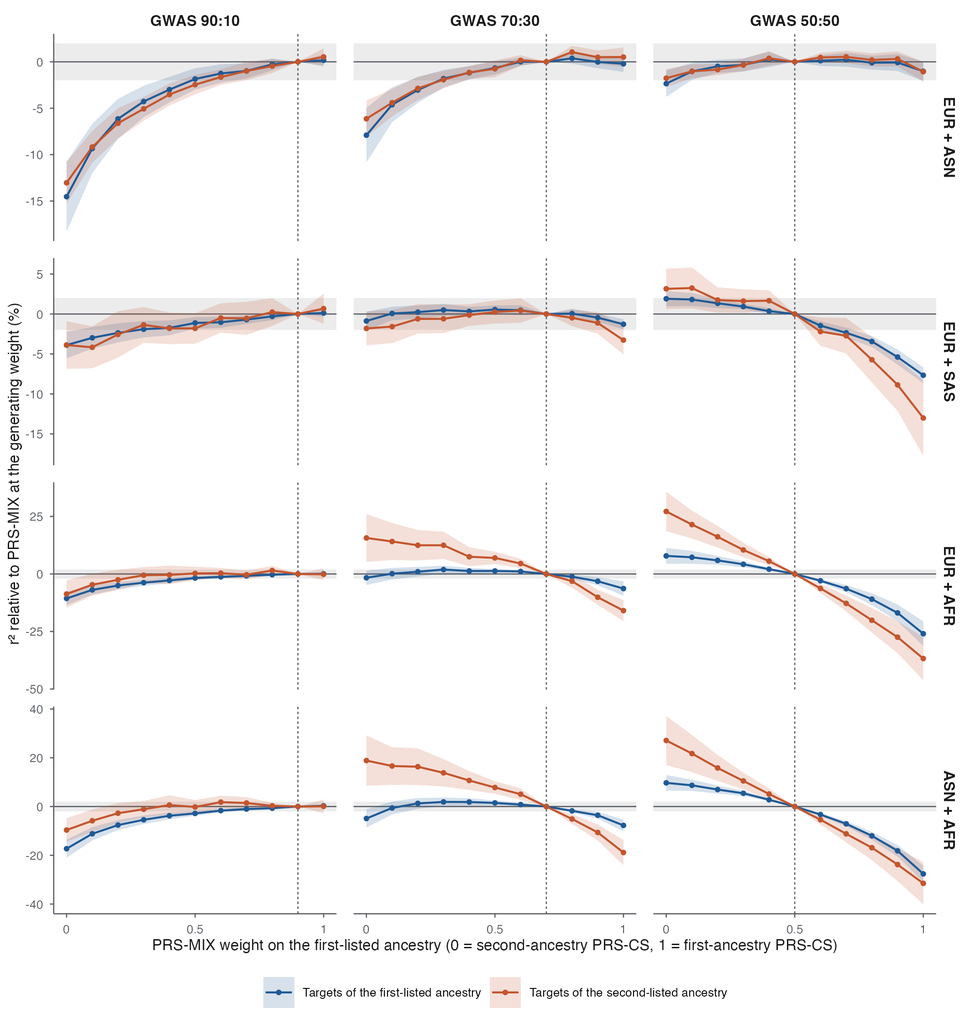

## Figure 2. Mean squared error across weights

Geometric-mean percentage change in MSE against the true genetic value relative to PRS-LDmix at the generating weight, with pointwise 95% intervals; negative is better; grey band ±2%. Free y-axis per row.

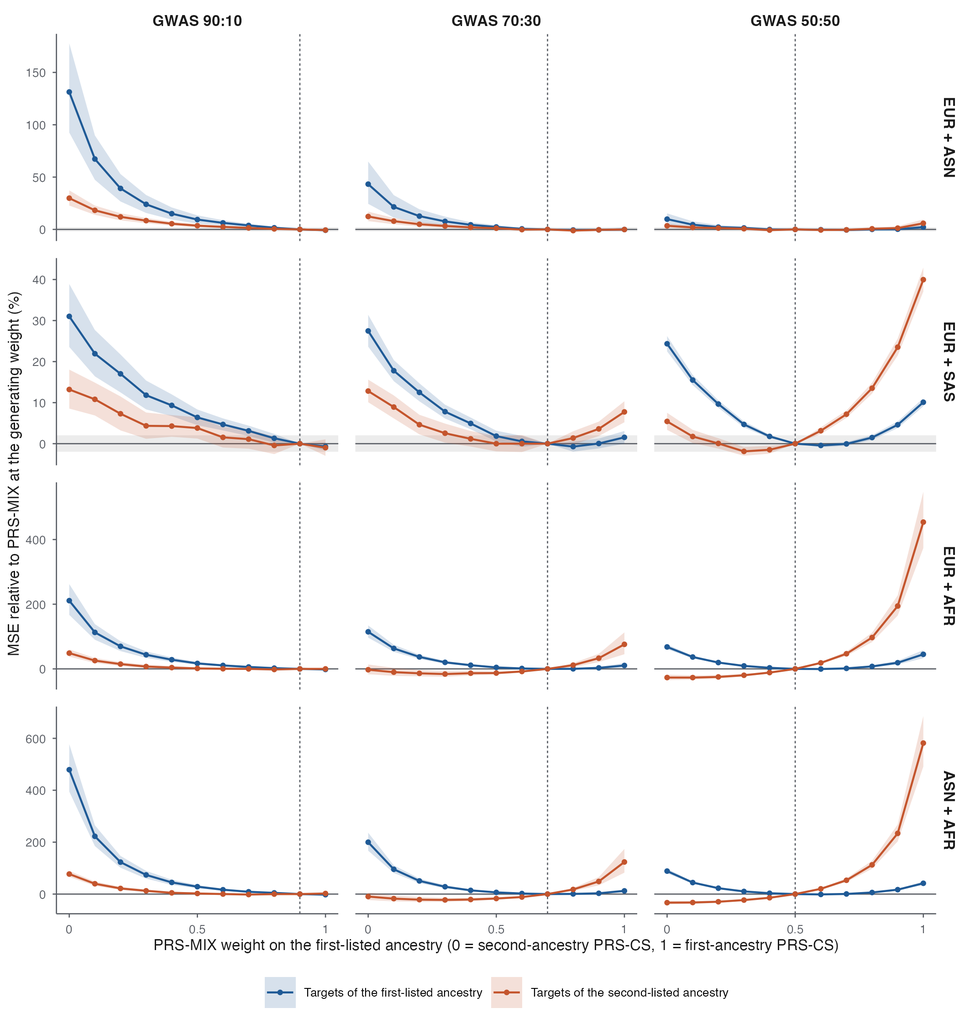